# lab2NB

```python
import numpy as np
import matplotlib
import matplotlib.pyplot as plt
import scipy
from scipy import stats
import math
plt.rcParams["figure.figsize"] = (10,7)
```

#### problem 1

#### for a poisson distribution P(x, λ ) =(e^(-λ)* (λ^x))/x!

#### A) Show how the probability distribution of the background changes as you integrate (sum) for more days

```python
stats.poisson.pmf(np.arange(1,10), 5)
```

```
array([0.03368973, 0.08422434, 0.1403739 , 0.17546737, 0.17546737,
       0.14622281, 0.10444486, 0.06527804, 0.03626558])
```

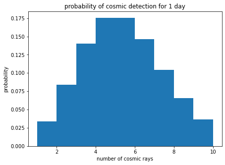

```python
plt.rcParams["figure.figsize"] = (7,5)
fig, ax = plt.subplots(1, 1, sharex = True, sharey = True)
ax.stairs( stats.poisson.pmf(np.arange(1,10), 5),np.arange(1,11),fill = True)

ax.set_xlabel("number of cosmic rays")
ax.set_ylabel("probability")
#ax.plot(np.linspace(10,60,1000),stats.norm.pdf(np.linspace(10,60,1000),loc = 35.5, scale = 5),linewidth = 8,alpha = 0.7)
plt.title("probability of cosmic detection for 1 day")
plt.show()
```

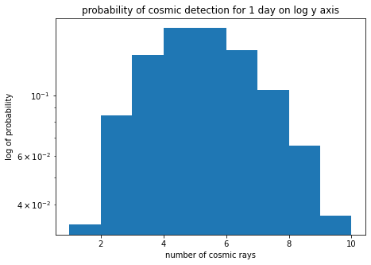

```python
plt.rcParams["figure.figsize"] = (7,5)
fig, ax = plt.subplots(1, 1, sharex = True, sharey = True)
ax.stairs( stats.poisson.pmf(np.arange(1,10), 5),np.arange(1,11),fill = True)

ax.set_xlabel("number of cosmic rays")
ax.set_ylabel("log of probability")
ax.set_yscale("log")
#ax.plot(np.linspace(10,60,1000),stats.norm.pdf(np.linspace(10,60,1000),loc = 35.5, scale = 5),linewidth = 8,alpha = 0.7)
plt.title("probability of cosmic detection for 1 day on log y axis")
plt.show()
```

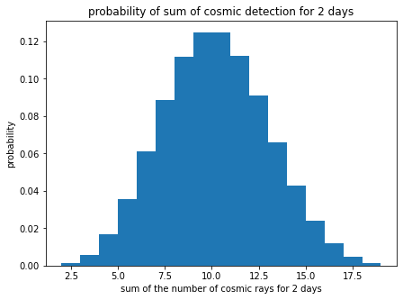

```python
v2 = stats.poisson.pmf(np.arange(1,10), 5)
v = v2
for x in range(1) :
    v2 = np.convolve(v, v2)
plt.rcParams["figure.figsize"] = (7,5)
fig, ax = plt.subplots(1, 1, sharex = True, sharey = True)
ax.stairs( v2,np.arange(2,20),fill = True)
plt.title("probability of sum of cosmic detection for 2 days")
ax.set_xlabel("sum of the number of cosmic rays for 2 days")
ax.set_ylabel("probability")
#ax.plot(np.linspace(10,60,1000),stats.norm.pdf(np.linspace(10,60,1000),loc = 35.5, scale = 5),linewidth = 8,alpha = 0.7)
#ax.set_yscale("log")
plt.show()
```

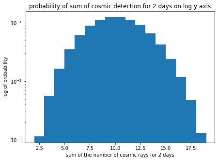

```python
v2 = stats.poisson.pmf(np.arange(1,10), 5)
v = v2
for x in range(1) :
    v2 = np.convolve(v, v2)
plt.rcParams["figure.figsize"] = (7,5)
fig, ax = plt.subplots(1, 1, sharex = True, sharey = True)
ax.stairs( v2,np.arange(2,20),fill = True)
plt.title("probability of sum of cosmic detection for 2 days on log y axis")
ax.set_xlabel("sum of the number of cosmic rays for 2 days")
ax.set_ylabel("log of probability")
#ax.plot(np.linspace(10,60,1000),stats.norm.pdf(np.linspace(10,60,1000),loc = 35.5, scale = 5),linewidth = 8,alpha = 0.7)
ax.set_yscale("log")
plt.show()
```

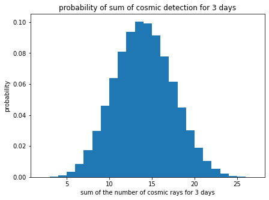

```python
v2 = stats.poisson.pmf(np.arange(1,10), 5)
v = v2
for x in range(2) :
    v2 = np.convolve(v, v2)
plt.rcParams["figure.figsize"] = (7,5)
fig, ax = plt.subplots(1, 1, sharex = True, sharey = True)
ax.stairs( v2,np.arange(2,28),fill = True)
plt.title("probability of sum of cosmic detection for 3 days")
ax.set_xlabel("sum of the number of cosmic rays for 3 days")
ax.set_ylabel("probability")
#ax.plot(np.linspace(10,60,1000),stats.norm.pdf(np.linspace(10,60,1000),loc = 35.5, scale = 5),linewidth = 8,alpha = 0.7)
#ax.set_yscale("log")
plt.show()
```

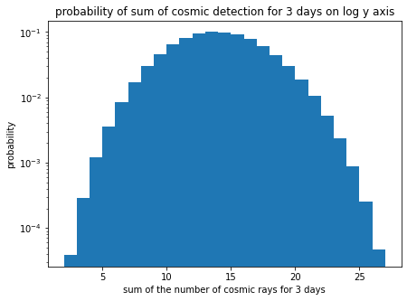

```python
v2 = stats.poisson.pmf(np.arange(1,10), 5)
v = v2
for x in range(2) :
    v2 = np.convolve(v, v2)
plt.rcParams["figure.figsize"] = (7,5)
fig, ax = plt.subplots(1, 1, sharex = True, sharey = True)
ax.stairs( v2,np.arange(2,28),fill = True)
plt.title("probability of sum of cosmic detection for 3 days on log y axis")
ax.set_xlabel("sum of the number of cosmic rays for 3 days")
ax.set_ylabel("probability")
#ax.plot(np.linspace(10,60,1000),stats.norm.pdf(np.linspace(10,60,1000),loc = 35.5, scale = 5),linewidth = 8,alpha = 0.7)
ax.set_yscale("log")
plt.show()
```

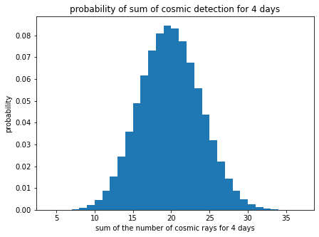

```python
v2 = stats.poisson.pmf(np.arange(1,10), 5)
v = v2
for x in range(3) :
    v2 = np.convolve(v, v2)
plt.rcParams["figure.figsize"] = (7,5)
fig, ax = plt.subplots(1, 1, sharex = True, sharey = True)
ax.stairs( v2,np.arange(4,38),fill = True)
plt.title("probability of sum of cosmic detection for 4 days")
ax.set_xlabel("sum of the number of cosmic rays for 4 days")
ax.set_ylabel("probability")
#ax.plot(np.linspace(10,60,1000),stats.norm.pdf(np.linspace(10,60,1000),loc = 35.5, scale = 5),linewidth = 8,alpha = 0.7)
#ax.set_yscale("log")
plt.show()
```

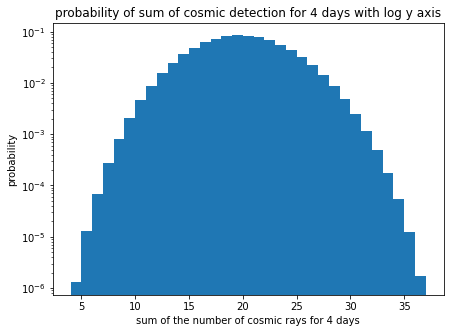

```python
v2 = stats.poisson.pmf(np.arange(1,10), 5)
v = v2
for x in range(3) :
    v2 = np.convolve(v, v2)
plt.rcParams["figure.figsize"] = (7,5)
fig, ax = plt.subplots(1, 1, sharex = True, sharey = True)
ax.stairs( v2,np.arange(4,38),fill = True)
plt.title("probability of sum of cosmic detection for 4 days with log y axis")
ax.set_xlabel("sum of the number of cosmic rays for 4 days")
ax.set_ylabel("probability")
#ax.plot(np.linspace(10,60,1000),stats.norm.pdf(np.linspace(10,60,1000),loc = 35.5, scale = 5),linewidth = 8,alpha = 0.7)
ax.set_yscale("log")
plt.show()
```

As we integrate the poisson distribution for more days we can see that the distribution (for plots for both regular and log y axis) becomes more and more gaussian like.As the number of days increases the range of sum of number of rays increases but the probability of the mean decreases as the sum of all probabilities is 1.

#### B) Show that after 5 days, the summed probability distribution is still a Poisson distribution. Explain why this makes sense from a mathematical and conceptual point of view.

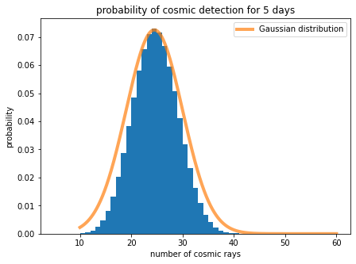

```python
v2 = stats.poisson.pmf(np.arange(1,10), 5)
v = v2
for x in range(4) :
    v2 = np.convolve(v, v2)
plt.rcParams["figure.figsize"] = (7,5)
fig, ax = plt.subplots(1, 1, sharex = True, sharey = True)
ax.stairs(v2, np.arange(5,47),fill = True)
plt.title("probability of cosmic detection for 5 days")
ax.set_xlabel("number of cosmic rays")
ax.set_ylabel("probability")
ax.plot(np.linspace(10,60,1000),stats.norm.pdf(np.linspace(10,60,1000),loc = 24.5, scale = 5.5),linewidth = 4,alpha = 0.7, label='Gaussian distribution')
#ax.set_yscale("log")
ax.legend()
plt.show()
```

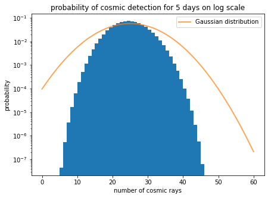

```python
v2 = stats.poisson.pmf(np.arange(1,10), 5)
v = v2
for x in range(4) :
    v2 = np.convolve(v, v2)
plt.rcParams["figure.figsize"] = (7,5)
fig, ax = plt.subplots(1, 1, sharex = True, sharey = True)
ax.stairs(v2, np.arange(5,47),fill = True)
plt.title("probability of cosmic detection for 5 days on log scale")
ax.set_xlabel("number of cosmic rays")
ax.set_ylabel("probability")
ax.plot(np.linspace(0,60,1000),stats.norm.pdf(np.linspace(0,60,1000),loc = 25, scale = 7),linewidth = 2,alpha = 0.7, label='Gaussian distribution')
ax.set_yscale("log")
plt.legend()
plt.show()
```

Explanation: Mathematical : The convolution of independent Poisson distributions is still a Poisson distribution.As the value of mu adds up mu = mu1 + mu2+ mu3 + m4+...+mun This can be verified using equations.

Conceptual :The distribution is discrete unlike gaussian summing up discrete values does not give continuous values.

#### C) Show how the probability distribution evolves as you average days. Calculate for many different ranges of days, and explore the shape of the distribution as the number of days becomes larger. Discuss this in relation to both B) and the central limit theoem.

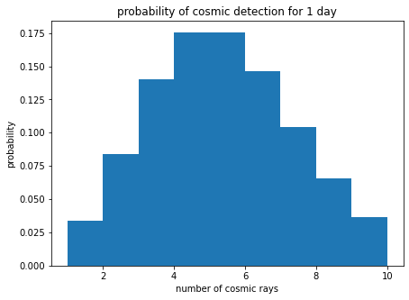

```python
plt.rcParams["figure.figsize"] = (7,5)
fig, ax = plt.subplots(1, 1, sharex = True, sharey = True)
ax.stairs( stats.poisson.pmf(np.arange(1,10), 5),np.arange(1,11),fill = True)
plt.title("probability of cosmic detection for 1 day")
ax.set_xlabel("number of cosmic rays")
ax.set_ylabel("probability")
#ax.plot(np.linspace(10,60,1000),stats.norm.pdf(np.linspace(10,60,1000),loc = 35.5, scale = 5),linewidth = 8,alpha = 0.7)
#ax.set_yscale("log")
plt.show()
```

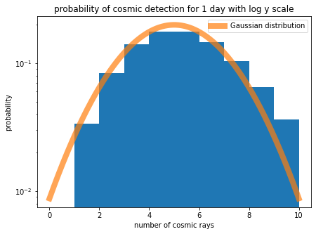

```python
plt.rcParams["figure.figsize"] = (7,5)
fig, ax = plt.subplots(1, 1, sharex = True, sharey = True)
ax.stairs( stats.poisson.pmf(np.arange(1,10), 5),np.arange(1,11),fill = True)
plt.title("probability of cosmic detection for 1 day with log y scale")
ax.set_xlabel("number of cosmic rays")
ax.set_ylabel("probability")
ax.plot(np.linspace(0,10,1000),stats.norm.pdf(np.linspace(0,10,1000),loc = 5, scale = 2),linewidth = 8,alpha = 0.7, label='Gaussian distribution')
ax.set_yscale("log")
ax.legend()
plt.show()
```

Average for 2 days:

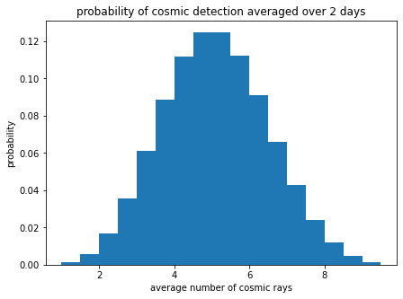

```python
v2 = stats.poisson.pmf(np.arange(1,10), 5)
v = stats.poisson.pmf(np.arange(1,10), 5)
v2 = np.convolve(v, v2)

plt.rcParams["figure.figsize"] = (7,5)
fig, ax = plt.subplots(1, 1, sharex = True, sharey = True)
ax.stairs( v2,np.arange(2,20)/2,fill = True)
plt.title("probability of cosmic detection averaged over 2 days")
ax.set_xlabel("average number of cosmic rays")
ax.set_ylabel("probability")
#ax.plot(np.linspace(10,60,1000),stats.norm.pdf(np.linspace(10,60,1000),loc = 35.5, scale = 5),linewidth = 8,alpha = 0.7)
#ax.set_yscale("log")
plt.show()
```

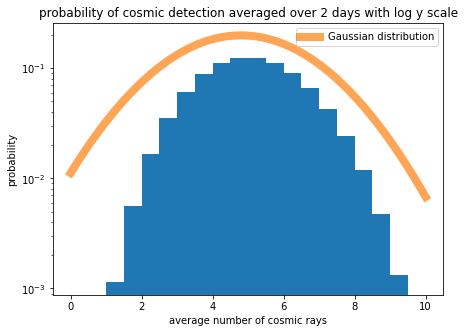

```python
v2 = stats.poisson.pmf(np.arange(1,10), 5)
v = stats.poisson.pmf(np.arange(1,10), 5)
v2 = np.convolve(v, v2)

plt.rcParams["figure.figsize"] = (7,5)
fig, ax = plt.subplots(1, 1, sharex = True, sharey = True)
ax.stairs( v2,np.arange(2,20)/2,fill = True)
plt.title("probability of cosmic detection averaged over 2 days with log y scale")
ax.set_xlabel("average number of cosmic rays")
ax.set_ylabel("probability")
ax.plot(np.linspace(0,10,1000),stats.norm.pdf(np.linspace(0,10,1000),loc =4.8, scale = 2),linewidth = 8,alpha = 0.7, label='Gaussian distribution')
ax.set_yscale("log")
ax.legend()
plt.show()
```

Average for 3 days:

```
25
```

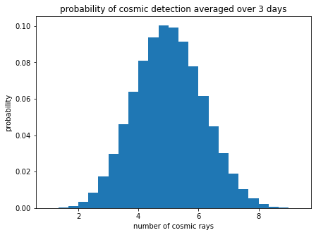

```python
v2 = stats.poisson.pmf(np.arange(1,10), 5)
v = stats.poisson.pmf(np.arange(1,10), 5)
for x in range(2) :
    v2 = np.convolve(v, v2)
print(len(v2))
plt.rcParams["figure.figsize"] = (7,5)
fig, ax = plt.subplots(1, 1, sharex = True, sharey = True)
ax.stairs(v2, np.arange(3,29)/3,fill = True)
plt.title("probability of cosmic detection averaged over 3 days")
ax.set_xlabel("number of cosmic rays")
ax.set_ylabel("probability")
#ax.plot(np.linspace(10,60,1000),stats.norm.pdf(np.linspace(10,60,1000),loc = 35.5, scale = 5),linewidth = 8,alpha = 0.7)
#ax.set_yscale("log")
plt.show()
```

```
25
```

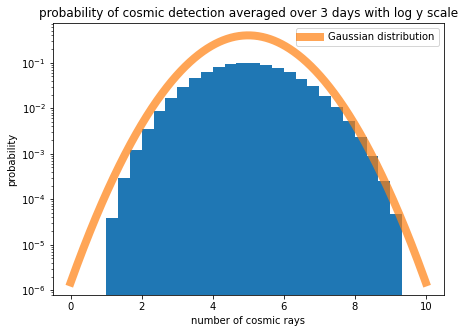

```python
v2 = stats.poisson.pmf(np.arange(1,10), 5)
v = stats.poisson.pmf(np.arange(1,10), 5)
for x in range(2) :
    v2 = np.convolve(v, v2)
print(len(v2))
plt.rcParams["figure.figsize"] = (7,5)
fig, ax = plt.subplots(1, 1, sharex = True, sharey = True)
ax.stairs(v2, np.arange(3,29)/3,fill = True)
plt.title("probability of cosmic detection averaged over 3 days with log y scale")
ax.set_xlabel("number of cosmic rays")
ax.set_ylabel("probability")
ax.plot(np.linspace(0,10,1000),stats.norm.pdf(np.linspace(0,10,1000),loc = 5, scale = 1),linewidth = 8,alpha = 0.7, label='Gaussian distribution')
ax.set_yscale("log")
plt.legend()
plt.show()
```

As the number of days increases the distribution approaches Gaussian distribution. This consistent with the Central Limit Theorem that states that when independent random variables are summed up, their properly normalized sum tends toward a normal distribution even if the original variables themselves are not normally distributed.Similar to part B from the plot with the log y axis we can see that the distribution is not gaussian and it is slightlty skewed to the left.The distribution is discrete unlike gaussian summing up discrete values does not give continuous values. The distribution is still poisson for the same reasons discussed in part B.

#### D) Pick some number of days N, and assume you saw Y*N gamma rays from your source. Calculate the 'sigma' of your observation. [In reality the number of gamma-rays seen from a source will also fluctuate, but we're going to ignore that complication for a couple of labs.]

For 5 days we assume we saw 30 gamma rays.To get the sigma of the observation we get the probability of the sum of detections from the background is 30 or more then we use norm.ppf to convert this probability into significance value

```python
v2 = stats.poisson.pmf(np.arange(1,10), 5)
v = stats.poisson.pmf(np.arange(1,10), 5)
for x in range(4) :
    v2 = np.convolve(v, v2)
p = v2[30:].sum()
stats.norm.ppf(p)
```

```
-2.3888792275010116
```

The sigma value for the observation is 2.3888792275010116

#### Problem 2

#### Pick a skewed continuous distribtuion, such as a Rayleigh, that describes your background over some observing interval.

#### A) Show how the distribution changes as you average over more observing intervals.

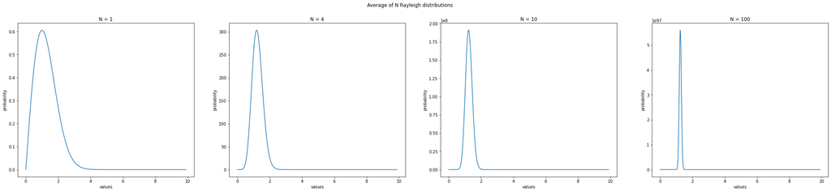

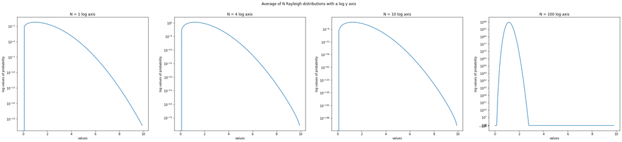

```python
# n= 1
x = np.arange(0,10,.1)
d = stats.rayleigh.pdf(x)
#plt.rcParams["figure.figsize"] = (7,5)
fig, ax = plt.subplots(1,4, figsize = (36, 7))
ax[0].plot(x,d)

ax[0].set_title("N = 1")
ax[0].set_xlabel("values")
ax[0].set_ylabel("probability")
#plt.show()


# n = 4

x = np.arange(0,10,.1)
d = stats.rayleigh.pdf(x)
#plt.rcParams["figure.figsize"] = (7,5)
d1 = d
for n in range(3):
    d = np.convolve(d1, d)
ax[1].plot(np.arange(0,39.7,.1)/4, d)

ax[1].set_title("N = 4")
ax[1].set_xlabel("values")
ax[1].set_ylabel("probability")



# n = 10

x = np.arange(0,10,.1)
d = stats.rayleigh.pdf(x)
#plt.rcParams["figure.figsize"] = (7,5)
d1 = d
for n in range(9):
    d = np.convolve(d1, d)
ax[2].plot(np.arange(0,99.1,.1)/10, d)

ax[2].set_title("N = 10")
ax[2].set_xlabel("values")
ax[2].set_ylabel("probability")

# n = 100

x = np.arange(0,10,.1)
d = stats.rayleigh.pdf(x)
#plt.rcParams["figure.figsize"] = (7,5)
d1 = d
for n in range(99):
    d = np.convolve(d1, d)
ax[3].plot(np.arange(0,990.1,.1)/100, d)

ax[3].set_title("N = 100")
ax[3].set_xlabel("values")
ax[3].set_ylabel("probability")
plt.suptitle('Average of N Rayleigh distributions')
plt.show()

# for y axis as log

# n= 1
x = np.arange(0,10,.1)
d = stats.rayleigh.pdf(x)
#plt.rcParams["figure.figsize"] = (7,5)
fig, ax = plt.subplots(1,4, figsize = (36, 7))
ax[0].plot(x, d)
ax[0].set_yscale('log')
ax[0].set_title("N = 1 log axis")
ax[0].set_xlabel("values")
ax[0].set_ylabel("log values of probability")

#plt.show()


# n = 4

x = np.arange(0,10,.1)
d = stats.rayleigh.pdf(x)
#plt.rcParams["figure.figsize"] = (7,5)
d1 = d
for n in range(3):
    d = np.convolve(d1, d)
ax[1].plot(np.arange(0,39.7,.1) / 4, d)
ax[1].set_yscale('log')
ax[1].set_title("N = 4 log axis")
ax[1].set_xlabel("values")
ax[1].set_ylabel("log values of probability")



# n = 10

x = np.arange(0,10,.1)
d = stats.rayleigh.pdf(x)
#plt.rcParams["figure.figsize"] = (7,5)
d1 = d
for n in range(9):
    d = np.convolve(d1, d)
ax[2].plot(np.arange(0,99.1,.1) / 10, d)
ax[2].set_yscale('log')
ax[2].set_title("N = 10 log axis")
ax[2].set_xlabel("values")
ax[2].set_ylabel("log values of probability")
plt.yscale('symlog')

# n = 100

x = np.arange(.1,10,.1)
d = stats.rayleigh.pdf(x)
#plt.rcParams["figure.figsize"] = (7,5)
d1 = d
for n in range(99):
    d = np.convolve(d1, d)
ax[3].plot(np.arange(0,980.1,.1) / 100, d)
ax[3].set_yscale('log')
ax[3].set_title("N = 100 log axis")
ax[3].set_xlabel("values")
ax[3].set_ylabel("log values of probability")

plt.suptitle('Average of N Rayleigh distributions with a log y axis')
plt.yscale('symlog')
plt.show()
```

### The above plots show how the distribution changes as you average N Rayleigh distributions

#### B) Discuss how the shape changes. Does it approach a Gaussian distribution? If yes, after how many intervals?

As the number of Rayleigh distributions averaged increases the plot becomes more and more narrower the probability densities of values away from the mean decrease and the ones near the mean increase.Even though the distribution on the regular axis looks like it approaches Gaussian distribution as the number of intervals increases, from the plots with the log y axis we can see that even though the distribution approaches the Gaussian distribution at N = 100 it isn't still quite gaussian as it is assymetric with the center skewed to the left.

#### Problem 3 Version 1

We are using an optical telescope with a thermal noise background from the CCD (dark current, particularly an issue with older CCDs and/or infra-red CCDs). After flat-fielding, the background appears as a zero-mean Gaussian with constant width over the image. For this problem we are assuming the gaussian distribution for the bachground has a scale of .5 and a signal strength of 4.1.

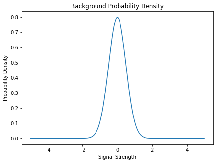

```python
x = np.linspace(-5,5, 1000)
d = stats.norm.pdf(x, loc = 0, scale = 0.5)
plt.plot(x, d)
plt.title("Background Probability Density")
plt.xlabel("Signal Strength")
plt.ylabel("Probability Density")
plt.show()
```

```python
p = 1 - stats.norm.cdf(4.1, loc = 0, scale = .5)

p
```

```
1.1102230246251565e-16
```

The probability of finding a signal with equal of greater strength is 1.1102230246251565e-16

```python
s = stats.norm.ppf(1 - p)
s
```

```
8.209536151601387
```

The significance of my detection (sigma) is: 8.209536151601387 This is greater than 5-sigma thus we can claim a discovery

#### Problem 3 Version 2 B

B) If you have to look for a signal in 10k pixels, what is the probability distribution of your background?

We need to get the probability that there would be a false detection of any of the 10k pixels.That is the probability of getting the particular pixel OR any other minus the probability of getting that particular pixel.

P(total) = 10000 * P - p ^ 10000

as p^1000 is insignificant for values with small p

P(total) is approximately 10000 * P

### Problem 3 Version 2 C

Taking your brightest candidate signal from the region.calculate the significance of your detection.

```python
P_total = 10000 * p
P_total
```

```
1.1102230246251565e-12
```

the probability that there would be a false detection of signal strength of 4.1 is 1.1102230246251565e-12

```python
s = stats.norm.ppf(1 - P_total)
s
```

```
7.019888982373347
```

The significance of the detection is 7.019888982373347

#### Problem 4 A

The signal required for a 5-sigma detection where the background from the the CCD has a gaussian distribution with mean at 0 and scale of .5.

```python
prob = 1 - stats.norm.cdf(5)
prob
```

```
2.866515719235352e-07
```

```python
v = stats.norm.ppf(1 - prob, loc = 0, scale = .5)
v
```

```
2.499999999985088
```

Thus the signal required for a 5 sigma detection in this case is 2.499999999985088 or -2.499999999985088

#### Problem 4 B

The signal required for a 5-sigma detection where we have to look for a signal in 10k pixels

We need the probability of 1/10000 of the probability of the 5 sigma detection for 4A

```python
prob2 = 1 - (prob)/10000
v_10k = stats.norm.ppf(prob2, loc = 0, scale = .5)
v_10k
```

```
3.2752687434458276
```

#### Problem 4 C

```python
factor = v_10k/v
factor
```

```
1.3101075225442618
```

The signal needs to be 1.3101075225442618 times brighter for a trial factor of 10K. sensitivity penalty due to a trials factor for values at 5 sigma is very low because the values are very close to the Gaussian tail and have an extremely low height, multiplying the height with a value of 10k does have significant impact..

#### Problem 4 D

If you changed the trials factor significantly (orders of magnitude), how large is the effect on your 5-sigma sensitivity threshold?

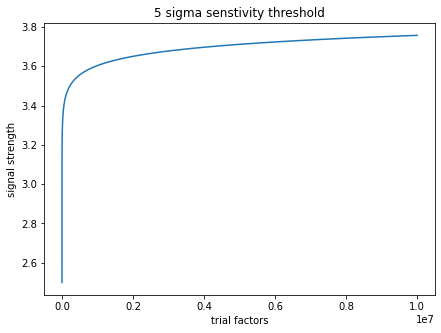

```python
x = np.arange(1,10000000)
plt.plot(x, stats.norm.ppf(1 -prob/x, loc = 0, scale = .5))
plt.title("5 sigma senstivity threshold")
plt.ylabel("signal strength")
plt.xlabel("trial factors")
plt.show()
```

The signal strength needed for 5sigma increases quickly for low trial factors, but then plateaus for higher values

If you had a different distribution shape (non-Gaussian), how would that affect the sensitivity penalty of many trials? Clearly explain.

Eventhough every distribution has a unique shape at the 5 sigma point, and thus will have a different sensitivity penalty. However for most distributions the 5 sigma coresponds to a point of low probability thus the senstivity penalty would be low. Lower the probability the point of 5 sigma corresponds to lower the senstivity penalty would be.

```python
import os
os.system('jupyter nbconvert --to html lab1NB.ipynb')
```

```
0
```